# DATA100 Introduction to Data Analytics

Lecture 7: Visualization Recap + Midterm Review

Agassi Iu

Wilfrid Laurier University

2026-10-01

## What we’ve covered

In the past two weeks, we have covered:

- **Lecture 4**: the grammar of graphics with data, aesthetics, geoms, facets, stats, positions, coordinates
- **Lecture 5**: exploratory data analysis with variation, covariation, outliers, missing data, confounding
- **Lecture 6**: design principles with visual cues, honest axes, showing the data, easing comparisons

**Today’s Agenda**

We are going to review these concepts from above for next week’s midterm.

# Aesthetics and geoms

## Aesthetics at a glance

| Aesthetic | Controls | Mapping example |
| --- | --- | --- |
| `x`, `y` | position | `aes(x = displ, y = hwy)` |
| `color` | outline / point color | `aes(color = class)` |
| `fill` | interior color (bars, areas) | `aes(fill = class)` |
| `shape` | point symbol (≤6 levels) | `aes(shape = drv)` |
| `size` | point/line size (continuous only) | `aes(size = cty)` |
| `alpha` | transparency (continuous only) | `aes(alpha = year)` |

**Important**

Inside `aes()` = **mapping**, which is driven by data and you get a legend.

Outside `aes()`= **setting**, which is essentially a fixed constant, no legend.

## Mapping vs. setting

**Mapping**

Ties an aesthetic to a variable in your data. The value changes per row, and ggplot2 draws a legend. Written **inside** `aes()`.

**Setting**

Gives an aesthetic one fixed value for every point, no matter what the data says. No legend, since there’s nothing to decode. Written **outside** `aes()`.

```r
# Mapping: color depends on class, varies per point, gets a legend
ggplot(mpg, aes(x = displ, y = hwy)) +
  geom_point(aes(color = class))

# Setting: every point is blue, no legend
ggplot(mpg, aes(x = displ, y = hwy)) +
  geom_point(color = "blue")
```

**Trap**

`geom_point(aes(color = "blue"))` looks like a setting but is written inside `aes()`, so it’s a mapping to the constant string `"blue"`, producing one default-palette color and a stray one-entry legend.

## Try it yourself

Predict what happens if you move `color = "blue"` outside `aes()`.

## Geoms at a glance

| Chart type | Geom | Notes |
| --- | --- | --- |
| Scatterplot | `geom_point()` | default position `"identity"` |
| Jittered scatter | `geom_jitter()` | same as `geom_point(position = "jitter")` |
| Trend line | `geom_smooth()` | `se = FALSE` drops the confidence band |
| Histogram | `geom_histogram()` | needs `binwidth`; continuous x |
| Bar chart (counts) | `geom_bar()` | uses `stat_count()` automatically |
| Bar chart (values) | `geom_col()` | uses `stat_identity()`, needs `y` |
| Boxplot | `geom_boxplot()` | five-number summary + outliers |
| Frequency polygon | `geom_freqpoly()` | line version of a histogram |

# facets, positions, stats

## Facets

| Function | Splits by | Layout |
| --- | --- | --- |
| `facet_wrap(~var)` | one variable | wraps into a grid automatically |
| `facet_grid(rows ~ cols)` | one or two variables | fixed rows/columns |
| `facet_grid(var ~ .)` | one variable | forced into rows |
| `facet_grid(. ~ var)` | one variable | forced into columns |

**Note**

`scales = "free"` (or `"free_x"`/`"free_y"`) lets each panel use its own axis range — easier to read within a panel, but panels are no longer directly comparable.

## Position adjustments

| Position | Effect | Best for |
| --- | --- | --- |
| `"identity"` | draws values exactly where they fall | points; overlapping bars need `alpha` |
| `"stack"` | segments piled up | default for bars |
| `"fill"` | stacked, normalized to 100% | comparing **proportions** |
| `"dodge"` | segments side by side | comparing **raw counts** |
| `"jitter"` | small random noise added | reducing overplotting in scatterplots |

## Stats and `after_stat()`

Every geom has a default **stat** that computes what actually gets plotted. For `geom_bar()`, that default is `count`: the number of rows in each group. You never have to ask for it explicitly.

**`after_stat()`**

Lets you reach into the stat’s output and ask for a *different* computed variable instead of the default:

| Variable | Definition |
| --- | --- |
| `count` | number of observations per group (default) |
| `prop` | proportion of the total each group represents |
| `density` | count standardized so the area under the curve sums to 1 |

```r
ggplot(diamonds, aes(x = cut, y = after_stat(prop), group = 1)) + geom_bar()
```

## Count vs. proportion vs. density

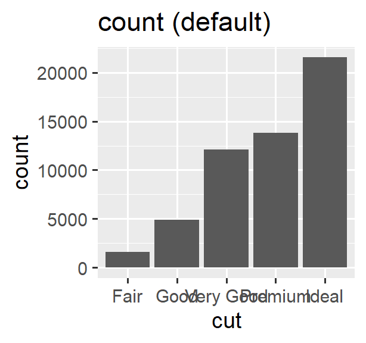

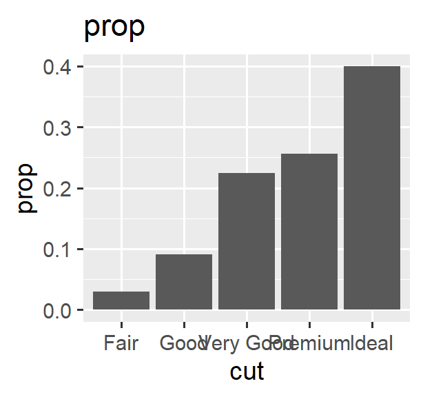

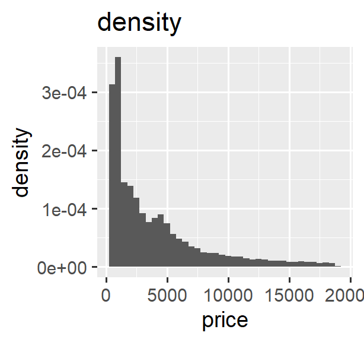

```r
ggplot(diamonds, aes(x = cut)) +
  geom_bar() +
  labs(title = "count (default)")
ggplot(diamonds, aes(x = cut, y = after_stat(prop), group = 1)) +
  geom_bar() +
  labs(title = "prop")
ggplot(diamonds, aes(x = price, y = after_stat(density))) +
  geom_histogram(binwidth = 500) +
  labs(title = "density")
```

# labels and scales

## Labels

```r
labs(
  title = "States the finding, not the axes",
  subtitle = "Optional supporting detail",
  x = "Engine displacement (L)",
  y = "Highway mpg",
  color = "Vehicle class",
  caption = "Data source"
)
```

**Tip**

A good title tells the reader what to conclude. “Scatterplot of displ vs. hwy” wastes the most prominent text on the slide.

## Scales

| Function | Purpose |
| --- | --- |
| `coord_cartesian(xlim = ..., ylim = ...)` | zooms the view; refits nothing |
| `scale_x_continuous(limits = ...)` /`scale_y_continuous(limits = ...)` | discards data outside the range before any stat runs |

**Zooming**

`coord_cartesian()` and scale `limits` both “zoom,” but only one of them actually refits a `geom_smooth()` curve on less data.

# Variation vs. covariation

## The distinction

**Variation**

How much a single variable’s values differ from one observation to the next.

**Covariation**

The tendency for two or more variables to move together. If two variables covary, knowing one improves your guess about the other.

| Comparison type | Tool |
| --- | --- |
| One numeric variable | histogram, density, boxplot |
| Categorical × numeric | boxplot, faceted histogram, colored freqpoly |
| Categorical × categorical | `geom_count()`, `geom_tile()` (heat maps) |
| Numeric × numeric | scatterplot, binned boxplots |

# Reading plots: practice

## Interpretation 1: boxplot

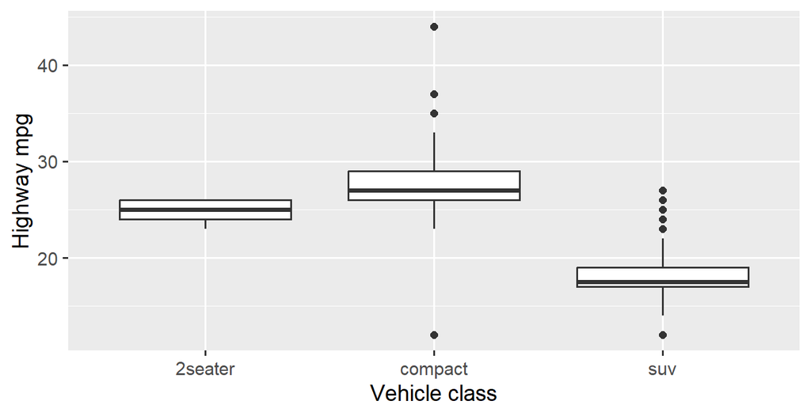

**Questions**

1. Which class shows the most variation in `hwy`?
2. Is there evidence of covariation between `class` and `hwy`?
3. Does any class show a labeled outlier? How does a boxplot decide that?
4. Rank the three classes by median, best to worst mpg.

## Interpretation 2: scatterplot

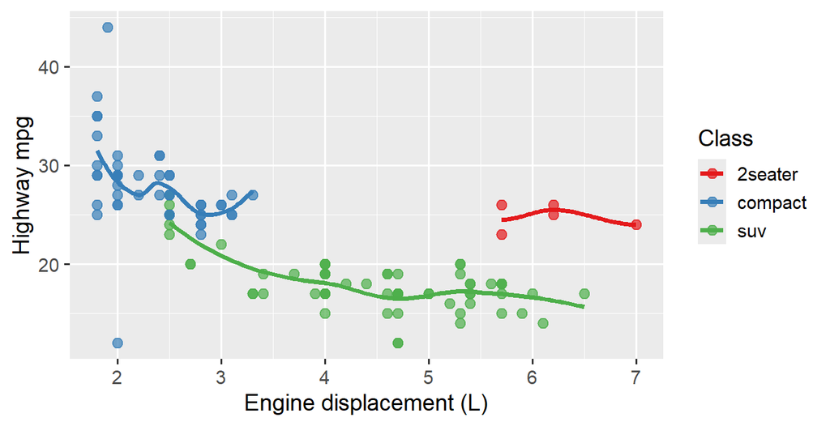

**Questions**

1. Which class shows the most spread, and in which direction (x, y, or both)?
2. Within one class, does `hwy` fall as `displ` rises?
3. Do the three classes occupy separate regions, or do they overlap?

# Live practice

## Exercise 1: aesthetics and geoms

**Tip**

Using `subgroup_data`, build a scatterplot of `hwy` vs. `displ`. Map colour to `class`, and make the points partially transparent.

## Exercise 2: facets and positions

**Tip**

Build a bar chart of `class` counts, filled by `drv`, with bars **side by side** rather than stacked. Then facet the same plot by `drv`.

## Exercise 3: labels and scales

**Tip**

Take the plot from Exercise 1 and add a title that states a finding, proper axis labels, and a ColorBrewer palette.

## Final tips before your exam

- Review the slides and textbook (*R for Data Science*).
- Go over the pre-lab and lab assignment solutions.
  - Make sure that you understand the material.
- Review your cheat sheet
  - please write your own: An authentic formula sheet will be far more useful than a sheet that you have never read before, written by your friend.
- I still have office hours from 2 to 4pm on next Monday, October 5!
- Practice reading a plot cold: variation, covariation, outliers, labels.